# Risk Factor Analysis

## Outcome Variable

**Outcome Variable:** swasted

## Predictor Variables

**Intervention Variable:** impsan

**Adjustment Set:**

- arm
- sex
- W_mage
- meducyrs
- feducyrs
- hhwealth_quart
- hfoodsec
- W_mhtcm
- W_mwtkg
- W_mbmi
- W_nrooms
- W_nchldlt5
- W_parity
- impfloor
- safeh20
- delta_W_mage
- delta_meducyrs
- delta_feducyrs
- delta_hhwealth_quart
- delta_hfoodsec
- delta_W_mhtcm
- delta_W_mwtkg
- delta_W_mbmi
- delta_W_nrooms
- delta_W_nchldlt5
- delta_W_parity
- delta_impfloor
- delta_safeh20

## Stratifying Variables

The analysis was stratified on these variable(s):

- agecat
- studyid
- country

## Data Summary

| agecat | studyid | country | impsan | swasted | n_cell | n |
| --- | --- | --- | --- | --- | --- | --- |
| Birth | ki0047075b-MAL-ED | BANGLADESH | 1 | 0 | 161 | 201 |
| Birth | ki0047075b-MAL-ED | BANGLADESH | 1 | 1 | 7 | 201 |
| Birth | ki0047075b-MAL-ED | BANGLADESH | 0 | 0 | 32 | 201 |
| Birth | ki0047075b-MAL-ED | BANGLADESH | 0 | 1 | 1 | 201 |
| Birth | ki0047075b-MAL-ED | BRAZIL | 1 | 0 | 56 | 57 |
| Birth | ki0047075b-MAL-ED | BRAZIL | 1 | 1 | 0 | 57 |
| Birth | ki0047075b-MAL-ED | BRAZIL | 0 | 0 | 1 | 57 |
| Birth | ki0047075b-MAL-ED | BRAZIL | 0 | 1 | 0 | 57 |
| Birth | ki0047075b-MAL-ED | INDIA | 1 | 0 | 14 | 39 |
| Birth | ki0047075b-MAL-ED | INDIA | 1 | 1 | 0 | 39 |
| Birth | ki0047075b-MAL-ED | INDIA | 0 | 0 | 25 | 39 |
| Birth | ki0047075b-MAL-ED | INDIA | 0 | 1 | 0 | 39 |
| Birth | ki0047075b-MAL-ED | NEPAL | 1 | 0 | 23 | 25 |
| Birth | ki0047075b-MAL-ED | NEPAL | 1 | 1 | 1 | 25 |
| Birth | ki0047075b-MAL-ED | NEPAL | 0 | 0 | 1 | 25 |
| Birth | ki0047075b-MAL-ED | NEPAL | 0 | 1 | 0 | 25 |
| Birth | ki0047075b-MAL-ED | PERU | 1 | 0 | 50 | 203 |
| Birth | ki0047075b-MAL-ED | PERU | 1 | 1 | 0 | 203 |
| Birth | ki0047075b-MAL-ED | PERU | 0 | 0 | 153 | 203 |
| Birth | ki0047075b-MAL-ED | PERU | 0 | 1 | 0 | 203 |
| Birth | ki0047075b-MAL-ED | SOUTH AFRICA | 1 | 0 | 0 | 94 |
| Birth | ki0047075b-MAL-ED | SOUTH AFRICA | 1 | 1 | 0 | 94 |
| Birth | ki0047075b-MAL-ED | SOUTH AFRICA | 0 | 0 | 94 | 94 |
| Birth | ki0047075b-MAL-ED | SOUTH AFRICA | 0 | 1 | 0 | 94 |
| Birth | ki0047075b-MAL-ED | TANZANIA, UNITED REPUBLIC OF | 1 | 0 | 0 | 110 |
| Birth | ki0047075b-MAL-ED | TANZANIA, UNITED REPUBLIC OF | 1 | 1 | 0 | 110 |
| Birth | ki0047075b-MAL-ED | TANZANIA, UNITED REPUBLIC OF | 0 | 0 | 110 | 110 |
| Birth | ki0047075b-MAL-ED | TANZANIA, UNITED REPUBLIC OF | 0 | 1 | 0 | 110 |
| Birth | ki1017093-NIH-Birth | BANGLADESH | 1 | 0 | 202 | 575 |
| Birth | ki1017093-NIH-Birth | BANGLADESH | 1 | 1 | 20 | 575 |

[output cut: 170 more lines]

The following strata were considered:

- agecat: 24 months, studyid: ki0047075b-MAL-ED, country: BANGLADESH
- agecat: 24 months, studyid: ki0047075b-MAL-ED, country: BRAZIL
- agecat: 24 months, studyid: ki0047075b-MAL-ED, country: INDIA
- agecat: 24 months, studyid: ki0047075b-MAL-ED, country: NEPAL
- agecat: 24 months, studyid: ki0047075b-MAL-ED, country: PERU
- agecat: 24 months, studyid: ki0047075b-MAL-ED, country: SOUTH AFRICA
- agecat: 24 months, studyid: ki0047075b-MAL-ED, country: TANZANIA, UNITED REPUBLIC OF
- agecat: 24 months, studyid: ki1017093-NIH-Birth, country: BANGLADESH
- agecat: 24 months, studyid: ki1017093b-PROVIDE, country: BANGLADESH
- agecat: 24 months, studyid: ki1017093c-NIH-Crypto, country: BANGLADESH
- agecat: 24 months, studyid: ki1114097-CONTENT, country: PERU
- agecat: 24 months, studyid: ki1135781-COHORTS, country: GUATEMALA
- agecat: 24 months, studyid: ki1135781-COHORTS, country: INDIA
- agecat: 24 months, studyid: ki1135781-COHORTS, country: PHILIPPINES
- agecat: 24 months, studyid: ki1148112-LCNI-5, country: MALAWI
- agecat: 24 months, studyid: kiGH5241-JiVitA-3, country: BANGLADESH
- agecat: 24 months, studyid: kiGH5241-JiVitA-4, country: BANGLADESH
- agecat: 6 months, studyid: ki0047075b-MAL-ED, country: BANGLADESH
- agecat: 6 months, studyid: ki0047075b-MAL-ED, country: BRAZIL
- agecat: 6 months, studyid: ki0047075b-MAL-ED, country: INDIA
- agecat: 6 months, studyid: ki0047075b-MAL-ED, country: NEPAL
- agecat: 6 months, studyid: ki0047075b-MAL-ED, country: PERU
- agecat: 6 months, studyid: ki0047075b-MAL-ED, country: SOUTH AFRICA
- agecat: 6 months, studyid: ki0047075b-MAL-ED, country: TANZANIA, UNITED REPUBLIC OF
- agecat: 6 months, studyid: ki1017093-NIH-Birth, country: BANGLADESH
- agecat: 6 months, studyid: ki1017093b-PROVIDE, country: BANGLADESH
- agecat: 6 months, studyid: ki1017093c-NIH-Crypto, country: BANGLADESH
- agecat: 6 months, studyid: ki1114097-CONTENT, country: PERU
- agecat: 6 months, studyid: ki1135781-COHORTS, country: GUATEMALA
- agecat: 6 months, studyid: ki1135781-COHORTS, country: INDIA
- agecat: 6 months, studyid: ki1135781-COHORTS, country: PHILIPPINES
- agecat: 6 months, studyid: ki1148112-LCNI-5, country: MALAWI
- agecat: 6 months, studyid: kiGH5241-JiVitA-3, country: BANGLADESH
- agecat: 6 months, studyid: kiGH5241-JiVitA-4, country: BANGLADESH
- agecat: Birth, studyid: ki0047075b-MAL-ED, country: BANGLADESH
- agecat: Birth, studyid: ki0047075b-MAL-ED, country: BRAZIL
- agecat: Birth, studyid: ki0047075b-MAL-ED, country: INDIA
- agecat: Birth, studyid: ki0047075b-MAL-ED, country: NEPAL
- agecat: Birth, studyid: ki0047075b-MAL-ED, country: PERU
- agecat: Birth, studyid: ki0047075b-MAL-ED, country: SOUTH AFRICA
- agecat: Birth, studyid: ki0047075b-MAL-ED, country: TANZANIA, UNITED REPUBLIC OF
- agecat: Birth, studyid: ki1017093-NIH-Birth, country: BANGLADESH
- agecat: Birth, studyid: ki1017093b-PROVIDE, country: BANGLADESH
- agecat: Birth, studyid: ki1017093c-NIH-Crypto, country: BANGLADESH
- agecat: Birth, studyid: ki1114097-CONTENT, country: PERU
- agecat: Birth, studyid: ki1135781-COHORTS, country: GUATEMALA
- agecat: Birth, studyid: ki1135781-COHORTS, country: INDIA
- agecat: Birth, studyid: ki1135781-COHORTS, country: PHILIPPINES
- agecat: Birth, studyid: kiGH5241-JiVitA-3, country: BANGLADESH
- agecat: Birth, studyid: kiGH5241-JiVitA-4, country: BANGLADESH

### Dropped Strata

Some strata were dropped due to rare outcomes:

- agecat: Birth, studyid: ki0047075b-MAL-ED, country: BANGLADESH
- agecat: Birth, studyid: ki0047075b-MAL-ED, country: BRAZIL
- agecat: Birth, studyid: ki0047075b-MAL-ED, country: INDIA
- agecat: Birth, studyid: ki0047075b-MAL-ED, country: NEPAL
- agecat: Birth, studyid: ki0047075b-MAL-ED, country: PERU
- agecat: Birth, studyid: ki0047075b-MAL-ED, country: SOUTH AFRICA
- agecat: Birth, studyid: ki0047075b-MAL-ED, country: TANZANIA, UNITED REPUBLIC OF
- agecat: Birth, studyid: ki1017093b-PROVIDE, country: BANGLADESH
- agecat: Birth, studyid: ki1114097-CONTENT, country: PERU
- agecat: 6 months, studyid: ki0047075b-MAL-ED, country: BANGLADESH
- agecat: 6 months, studyid: ki0047075b-MAL-ED, country: BRAZIL
- agecat: 6 months, studyid: ki0047075b-MAL-ED, country: INDIA
- agecat: 6 months, studyid: ki0047075b-MAL-ED, country: NEPAL
- agecat: 6 months, studyid: ki0047075b-MAL-ED, country: PERU
- agecat: 6 months, studyid: ki0047075b-MAL-ED, country: SOUTH AFRICA
- agecat: 6 months, studyid: ki0047075b-MAL-ED, country: TANZANIA, UNITED REPUBLIC OF
- agecat: 6 months, studyid: ki1017093-NIH-Birth, country: BANGLADESH
- agecat: 6 months, studyid: ki1017093b-PROVIDE, country: BANGLADESH
- agecat: 6 months, studyid: ki1017093c-NIH-Crypto, country: BANGLADESH
- agecat: 6 months, studyid: ki1114097-CONTENT, country: PERU
- agecat: 6 months, studyid: ki1135781-COHORTS, country: GUATEMALA
- agecat: 6 months, studyid: ki1135781-COHORTS, country: PHILIPPINES
- agecat: 6 months, studyid: ki1148112-LCNI-5, country: MALAWI
- agecat: 24 months, studyid: ki0047075b-MAL-ED, country: BANGLADESH
- agecat: 24 months, studyid: ki0047075b-MAL-ED, country: BRAZIL
- agecat: 24 months, studyid: ki0047075b-MAL-ED, country: INDIA
- agecat: 24 months, studyid: ki0047075b-MAL-ED, country: NEPAL
- agecat: 24 months, studyid: ki0047075b-MAL-ED, country: PERU
- agecat: 24 months, studyid: ki0047075b-MAL-ED, country: SOUTH AFRICA
- agecat: 24 months, studyid: ki0047075b-MAL-ED, country: TANZANIA, UNITED REPUBLIC OF
- agecat: 24 months, studyid: ki1017093-NIH-Birth, country: BANGLADESH
- agecat: 24 months, studyid: ki1017093b-PROVIDE, country: BANGLADESH
- agecat: 24 months, studyid: ki1017093c-NIH-Crypto, country: BANGLADESH
- agecat: 24 months, studyid: ki1114097-CONTENT, country: PERU
- agecat: 24 months, studyid: ki1135781-COHORTS, country: GUATEMALA
- agecat: 24 months, studyid: ki1135781-COHORTS, country: PHILIPPINES
- agecat: 24 months, studyid: ki1148112-LCNI-5, country: MALAWI

## Methods Detail

We’re interested in the causal parameters $E[Y_a]$ for all values of $a \in \mathcal{A}$. These parameters represent the mean outcome if, possibly contrary to fact, we intervened to set all units to have $A=a$. Under the randomization and positivity assumptions, these are identified by the statistical parameters $\psi_a=E_W[E_{Y|A,W}(Y|A=a,W)]$. In addition, we’re interested in the mean of $Y$, $E[Y]$ under no intervention (the observed mean). We will estimate these parameters by using SuperLearner to fit the relevant likelihood factors – $E_{Y|A,W}(Y|A=a,W)$ and $p(A=a|W)$, and then updating our likelihood fit using a joint TMLE.

For unadjusted analyses ($W=\{\}$), initial likelihoods were estimated using Lrnr_glm to estimate the simple $E(Y|A)$ and Lrnr_mean to estimate $p(A)$. For adjusted analyses, a small library containing Lrnr_glmnet, Lrnr_xgboost, and Lrnr_mean was used.

Having estimated these parameters, we will then use the delta method to estimate relative risks and attributable risks relative to a prespecified baseline level of $A$.

# Results Detail

## Results Plots

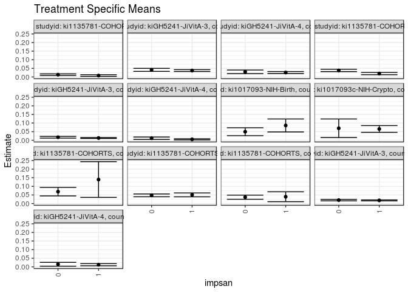

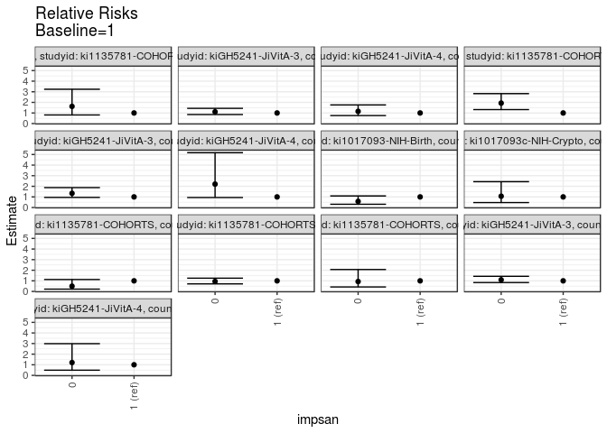

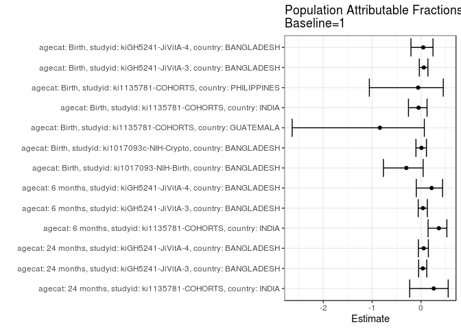

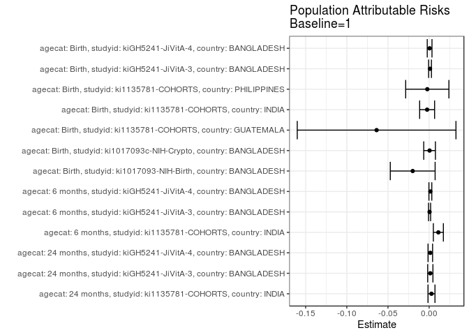

## Results Table

### Parameter: TSM

| agecat | studyid | country | intervention_level | baseline_level | estimate | ci_lower | ci_upper |
| --- | --- | --- | --- | --- | --- | --- | --- |
| Birth | ki1017093-NIH-Birth | BANGLADESH | 1 | NA | 0.0860447 | 0.0483648 | 0.1237246 |
| Birth | ki1017093-NIH-Birth | BANGLADESH | 0 | NA | 0.0496248 | 0.0266187 | 0.0726309 |
| Birth | ki1017093c-NIH-Crypto | BANGLADESH | 1 | NA | 0.0655738 | 0.0459161 | 0.0852315 |
| Birth | ki1017093c-NIH-Crypto | BANGLADESH | 0 | NA | 0.0697674 | 0.0158867 | 0.1236481 |
| Birth | ki1135781-COHORTS | GUATEMALA | 1 | NA | 0.1395349 | 0.0358522 | 0.2432175 |
| Birth | ki1135781-COHORTS | GUATEMALA | 0 | NA | 0.0689655 | 0.0442899 | 0.0936411 |
| Birth | ki1135781-COHORTS | INDIA | 1 | NA | 0.0504219 | 0.0392003 | 0.0616435 |
| Birth | ki1135781-COHORTS | INDIA | 0 | NA | 0.0476121 | 0.0394523 | 0.0557720 |
| Birth | ki1135781-COHORTS | PHILIPPINES | 1 | NA | 0.0395480 | 0.0108234 | 0.0682727 |
| Birth | ki1135781-COHORTS | PHILIPPINES | 0 | NA | 0.0368809 | 0.0248846 | 0.0488773 |
| Birth | kiGH5241-JiVitA-3 | BANGLADESH | 1 | NA | 0.0183192 | 0.0155242 | 0.0211142 |
| Birth | kiGH5241-JiVitA-3 | BANGLADESH | 0 | NA | 0.0200178 | 0.0156311 | 0.0244046 |
| Birth | kiGH5241-JiVitA-4 | BANGLADESH | 1 | NA | 0.0123722 | 0.0061302 | 0.0186143 |
| Birth | kiGH5241-JiVitA-4 | BANGLADESH | 0 | NA | 0.0149533 | 0.0037914 | 0.0261151 |
| 6 months | ki1135781-COHORTS | INDIA | 1 | NA | 0.0196281 | 0.0130326 | 0.0262236 |
| 6 months | ki1135781-COHORTS | INDIA | 0 | NA | 0.0378798 | 0.0310925 | 0.0446672 |
| 6 months | kiGH5241-JiVitA-3 | BANGLADESH | 1 | NA | 0.0131185 | 0.0105819 | 0.0156552 |
| 6 months | kiGH5241-JiVitA-3 | BANGLADESH | 0 | NA | 0.0175253 | 0.0124868 | 0.0225639 |
| 6 months | kiGH5241-JiVitA-4 | BANGLADESH | 1 | NA | 0.0053625 | 0.0020605 | 0.0086644 |
| 6 months | kiGH5241-JiVitA-4 | BANGLADESH | 0 | NA | 0.0118397 | 0.0050062 | 0.0186732 |
| 24 months | ki1135781-COHORTS | INDIA | 1 | NA | 0.0081659 | 0.0033281 | 0.0130038 |
| 24 months | ki1135781-COHORTS | INDIA | 0 | NA | 0.0132355 | 0.0085074 | 0.0179637 |
| 24 months | kiGH5241-JiVitA-3 | BANGLADESH | 1 | NA | 0.0372259 | 0.0317669 | 0.0426848 |
| 24 months | kiGH5241-JiVitA-3 | BANGLADESH | 0 | NA | 0.0412660 | 0.0325181 | 0.0500139 |
| 24 months | kiGH5241-JiVitA-4 | BANGLADESH | 1 | NA | 0.0258438 | 0.0199840 | 0.0317037 |
| 24 months | kiGH5241-JiVitA-4 | BANGLADESH | 0 | NA | 0.0297804 | 0.0192792 | 0.0402815 |

### Parameter: E(Y)

| agecat | studyid | country | intervention_level | baseline_level | estimate | ci_lower | ci_upper |
| --- | --- | --- | --- | --- | --- | --- | --- |
| Birth | ki1017093-NIH-Birth | BANGLADESH | NA | NA | 0.0660870 | 0.0457632 | 0.0864107 |
| Birth | ki1017093c-NIH-Crypto | BANGLADESH | NA | NA | 0.0660920 | 0.0476213 | 0.0845626 |
| Birth | ki1135781-COHORTS | GUATEMALA | NA | NA | 0.0757238 | 0.0512261 | 0.1002216 |
| Birth | ki1135781-COHORTS | INDIA | NA | NA | 0.0479713 | 0.0416994 | 0.0542432 |
| Birth | ki1135781-COHORTS | PHILIPPINES | NA | NA | 0.0373002 | 0.0262270 | 0.0483734 |
| Birth | kiGH5241-JiVitA-3 | BANGLADESH | NA | NA | 0.0193986 | 0.0169876 | 0.0218095 |
| Birth | kiGH5241-JiVitA-4 | BANGLADESH | NA | NA | 0.0129490 | 0.0075258 | 0.0183723 |
| 6 months | ki1135781-COHORTS | INDIA | NA | NA | 0.0308219 | 0.0260134 | 0.0356304 |
| 6 months | kiGH5241-JiVitA-3 | BANGLADESH | NA | NA | 0.0136529 | 0.0115802 | 0.0157256 |
| 6 months | kiGH5241-JiVitA-4 | BANGLADESH | NA | NA | 0.0068365 | 0.0038719 | 0.0098012 |
| 24 months | ki1135781-COHORTS | INDIA | NA | NA | 0.0110097 | 0.0076578 | 0.0143615 |
| 24 months | kiGH5241-JiVitA-3 | BANGLADESH | NA | NA | 0.0386361 | 0.0343091 | 0.0429631 |
| 24 months | kiGH5241-JiVitA-4 | BANGLADESH | NA | NA | 0.0272727 | 0.0220640 | 0.0324815 |

### Parameter: RR

| agecat | studyid | country | intervention_level | baseline_level | estimate | ci_lower | ci_upper |
| --- | --- | --- | --- | --- | --- | --- | --- |
| Birth | ki1017093-NIH-Birth | BANGLADESH | 1 | 1 | 1.0000000 | 1.0000000 | 1.000000 |
| Birth | ki1017093-NIH-Birth | BANGLADESH | 0 | 1 | 0.5767330 | 0.3046813 | 1.091701 |
| Birth | ki1017093c-NIH-Crypto | BANGLADESH | 1 | 1 | 1.0000000 | 1.0000000 | 1.000000 |
| Birth | ki1017093c-NIH-Crypto | BANGLADESH | 0 | 1 | 1.0639535 | 0.4646640 | 2.436162 |
| Birth | ki1135781-COHORTS | GUATEMALA | 1 | 1 | 1.0000000 | 1.0000000 | 1.000000 |
| Birth | ki1135781-COHORTS | GUATEMALA | 0 | 1 | 0.4942529 | 0.2166606 | 1.127505 |
| Birth | ki1135781-COHORTS | INDIA | 1 | 1 | 1.0000000 | 1.0000000 | 1.000000 |
| Birth | ki1135781-COHORTS | INDIA | 0 | 1 | 0.9442752 | 0.7130822 | 1.250425 |
| Birth | ki1135781-COHORTS | PHILIPPINES | 1 | 1 | 1.0000000 | 1.0000000 | 1.000000 |
| Birth | ki1135781-COHORTS | PHILIPPINES | 0 | 1 | 0.9325606 | 0.4207770 | 2.066817 |
| Birth | kiGH5241-JiVitA-3 | BANGLADESH | 1 | 1 | 1.0000000 | 1.0000000 | 1.000000 |
| Birth | kiGH5241-JiVitA-3 | BANGLADESH | 0 | 1 | 1.0927252 | 0.8370961 | 1.426417 |
| Birth | kiGH5241-JiVitA-4 | BANGLADESH | 1 | 1 | 1.0000000 | 1.0000000 | 1.000000 |
| Birth | kiGH5241-JiVitA-4 | BANGLADESH | 0 | 1 | 1.2086144 | 0.4883313 | 2.991307 |
| 6 months | ki1135781-COHORTS | INDIA | 1 | 1 | 1.0000000 | 1.0000000 | 1.000000 |
| 6 months | ki1135781-COHORTS | INDIA | 0 | 1 | 1.9298788 | 1.3185883 | 2.824560 |
| 6 months | kiGH5241-JiVitA-3 | BANGLADESH | 1 | 1 | 1.0000000 | 1.0000000 | 1.000000 |
| 6 months | kiGH5241-JiVitA-3 | BANGLADESH | 0 | 1 | 1.3359198 | 0.9511621 | 1.876317 |
| 6 months | kiGH5241-JiVitA-4 | BANGLADESH | 1 | 1 | 1.0000000 | 1.0000000 | 1.000000 |
| 6 months | kiGH5241-JiVitA-4 | BANGLADESH | 0 | 1 | 2.2078838 | 0.9426193 | 5.171495 |
| 24 months | ki1135781-COHORTS | INDIA | 1 | 1 | 1.0000000 | 1.0000000 | 1.000000 |
| 24 months | ki1135781-COHORTS | INDIA | 0 | 1 | 1.6208260 | 0.8114021 | 3.237701 |
| 24 months | kiGH5241-JiVitA-3 | BANGLADESH | 1 | 1 | 1.0000000 | 1.0000000 | 1.000000 |
| 24 months | kiGH5241-JiVitA-3 | BANGLADESH | 0 | 1 | 1.1085306 | 0.8544783 | 1.438117 |
| 24 months | kiGH5241-JiVitA-4 | BANGLADESH | 1 | 1 | 1.0000000 | 1.0000000 | 1.000000 |
| 24 months | kiGH5241-JiVitA-4 | BANGLADESH | 0 | 1 | 1.1523189 | 0.7549104 | 1.758936 |

### Parameter: PAR

| agecat | studyid | country | intervention_level | baseline_level | estimate | ci_lower | ci_upper |
| --- | --- | --- | --- | --- | --- | --- | --- |
| Birth | ki1017093-NIH-Birth | BANGLADESH | 1 | NA | -0.0199577 | -0.0471788 | 0.0072633 |
| Birth | ki1017093c-NIH-Crypto | BANGLADESH | 1 | NA | 0.0005182 | -0.0065695 | 0.0076059 |
| Birth | ki1135781-COHORTS | GUATEMALA | 1 | NA | -0.0638111 | -0.1602019 | 0.0325798 |
| Birth | ki1135781-COHORTS | INDIA | 1 | NA | -0.0024506 | -0.0115221 | 0.0066210 |
| Birth | ki1135781-COHORTS | PHILIPPINES | 1 | NA | -0.0022478 | -0.0284837 | 0.0239880 |
| Birth | kiGH5241-JiVitA-3 | BANGLADESH | 1 | NA | 0.0010794 | -0.0006364 | 0.0027952 |
| Birth | kiGH5241-JiVitA-4 | BANGLADESH | 1 | NA | 0.0005768 | -0.0022961 | 0.0034497 |
| 6 months | ki1135781-COHORTS | INDIA | 1 | NA | 0.0111938 | 0.0051027 | 0.0172850 |
| 6 months | kiGH5241-JiVitA-3 | BANGLADESH | 1 | NA | 0.0005344 | -0.0007226 | 0.0017913 |
| 6 months | kiGH5241-JiVitA-4 | BANGLADESH | 1 | NA | 0.0014741 | -0.0002697 | 0.0032179 |
| 24 months | ki1135781-COHORTS | INDIA | 1 | NA | 0.0028438 | -0.0013999 | 0.0070874 |
| 24 months | kiGH5241-JiVitA-3 | BANGLADESH | 1 | NA | 0.0014102 | -0.0017788 | 0.0045993 |
| 24 months | kiGH5241-JiVitA-4 | BANGLADESH | 1 | NA | 0.0014289 | -0.0013326 | 0.0041904 |

### Parameter: PAF

| agecat | studyid | country | intervention_level | baseline_level | estimate | ci_lower | ci_upper |
| --- | --- | --- | --- | --- | --- | --- | --- |
| Birth | ki1017093-NIH-Birth | BANGLADESH | 1 | NA | -0.3019919 | -0.7700897 | 0.0423181 |
| Birth | ki1017093c-NIH-Crypto | BANGLADESH | 1 | NA | 0.0078403 | -0.1053879 | 0.1094703 |
| Birth | ki1135781-COHORTS | GUATEMALA | 1 | NA | -0.8426813 | -2.6359609 | 0.0661412 |
| Birth | ki1135781-COHORTS | INDIA | 1 | NA | -0.0510844 | -0.2581065 | 0.1218721 |
| Birth | ki1135781-COHORTS | PHILIPPINES | 1 | NA | -0.0602637 | -1.0579534 | 0.4537490 |
| Birth | kiGH5241-JiVitA-3 | BANGLADESH | 1 | NA | 0.0556429 | -0.0365111 | 0.1396037 |
| Birth | kiGH5241-JiVitA-4 | BANGLADESH | 1 | NA | 0.0445435 | -0.2071576 | 0.2437632 |
| 6 months | ki1135781-COHORTS | INDIA | 1 | NA | 0.3631775 | 0.1426009 | 0.5270080 |
| 6 months | kiGH5241-JiVitA-3 | BANGLADESH | 1 | NA | 0.0391383 | -0.0583874 | 0.1276774 |
| 6 months | kiGH5241-JiVitA-4 | BANGLADESH | 1 | NA | 0.2156192 | -0.0977964 | 0.4395561 |
| 24 months | ki1135781-COHORTS | INDIA | 1 | NA | 0.2582964 | -0.2334445 | 0.5539935 |
| 24 months | kiGH5241-JiVitA-3 | BANGLADESH | 1 | NA | 0.0365004 | -0.0499355 | 0.1158206 |
| 24 months | kiGH5241-JiVitA-4 | BANGLADESH | 1 | NA | 0.0523924 | -0.0548568 | 0.1487373 |